# Lab 1, parte 4: correlações

José Ivan Silva da Cruz Júnior

```r
dados = read_projectdata()
```

A primeira correlação que iremos analisar é a que diz respeito ao número de seguidores e o engajamento total para todos os tweets vistos por parlamentar, incluindo likes e retweets. A segunda correlação a ser analisada trata do número de tweets próprios (o número de tweets que não são retweets) e o número de retweets. Iremos analisar a correlação entre essas variáveis.

1. Seguidores e engajamento total

Primeiro passo, iremos examinar o formato dos dados.

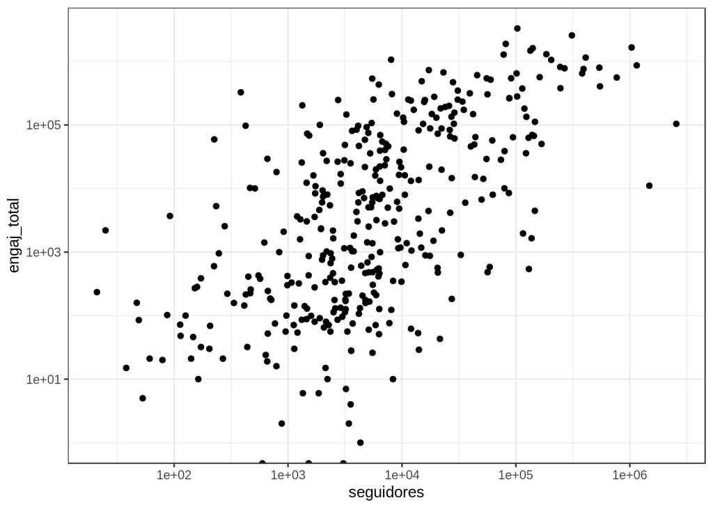

```r
dados %>% filter(!is.na(seguidores), !is.na(engaj_total)) %>%
  ggplot(aes(x = seguidores, y = engaj_total)) + geom_point() +
  scale_x_log10() +
  scale_y_log10()
```

Podemos ver pelo gráfico de pontos que o formato da correlação entre as duas variáveis é linear. Observamos também que não existem pontos tão extremos na correlação, a não ser dois parlamentares que possuem acima de 1 milhão de seguidores que possuem um engajamento total mediano.

Segundo passo, iremos examinar o sinal, força e valor da correlação.

```r
dados %>% filter(!is.na(seguidores), !is.na(engaj_total)) %>%
  summarise(correlação = cor(seguidores, engaj_total, method = "pearson"))
```

```
## # A tibble: 1 x 1
##   correlação
##        <dbl>
## 1      0.290
```

Temos uma correlação positiva medida por 0.29, logo, podemos dizer que a correlação entre as variáveis é fraca.

2. Número de tweets próprios e número de retweets

Primeiro passo, iremos examinar o formato dos dados.

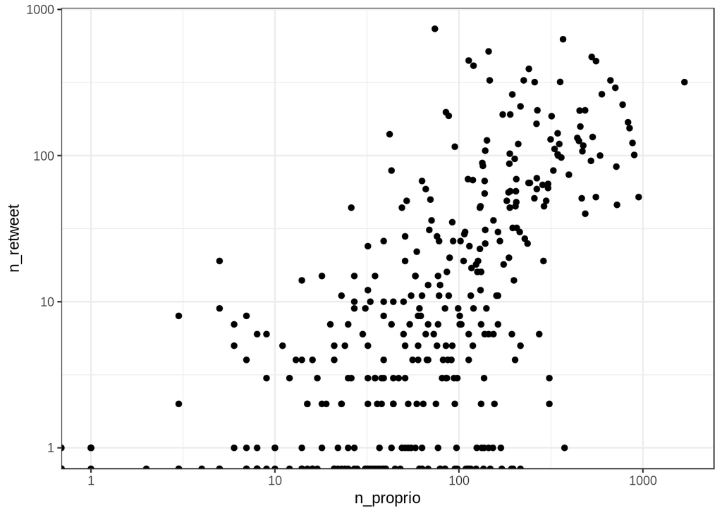

```r
dados %>% filter(!is.na(n_proprio), !is.na(n_retweet)) %>%
  ggplot(aes(x = n_proprio, y = n_retweet)) + geom_point() +
  scale_x_log10() +
  scale_y_log10()
```

Segundo passo, iremos examinar o sinal, força e valor da correlação.

```r
dados %>% filter(!is.na(n_proprio), !is.na(n_retweet)) %>%
  summarise(correlação = cor(n_proprio, n_retweet, method = "pearson"))
```

```
## # A tibble: 1 x 1
##   correlação
##        <dbl>
## 1      0.533
```

Temos uma correlação positiva medida por 0.53, assim, podemos dizer que a correlação entre as variáveis é moderada.